# Social Media Assigment

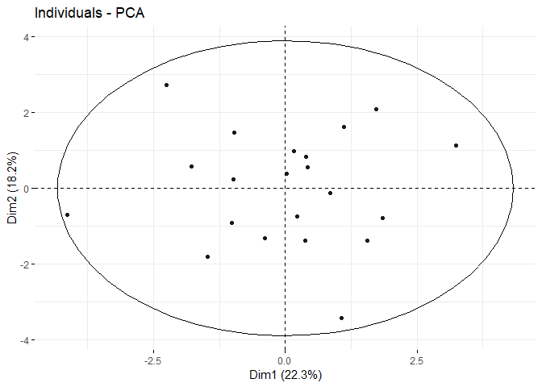

```r
# Visualize Individual Contributions
fviz_pca_ind(pca_result,
             geom.ind = "point", # Show points only
             palette = c("#00AFBB", "#E7B800", "#FC4E07"),
             addEllipses = TRUE, # Concentration ellipses
             legend.title = "Groups"
)
```

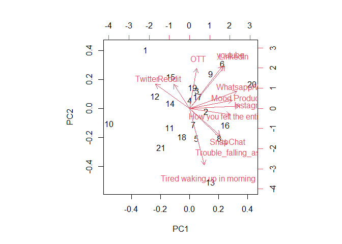

```r
# Biplot
biplot(pca_result)
```

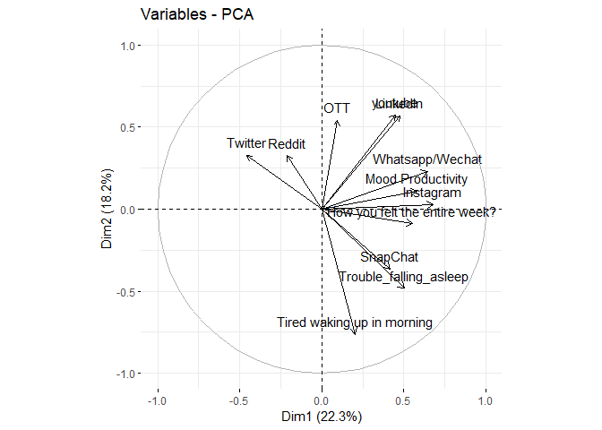

```r
# Variable correlation plot (Correlation Circle)
fviz_pca_var(pca_result, col.var = "black")
```

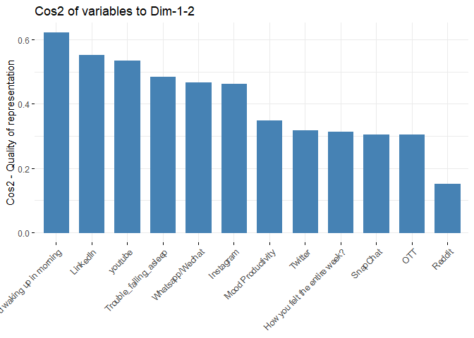

```r
# Quality of representation of variables on dimensions 1 and 2
fviz_cos2(pca_result, choice = "var", axes = 1:2)
```

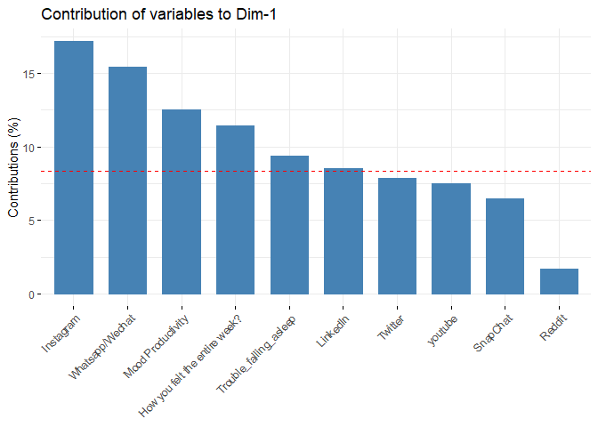

```r
# Contributions of variables to principal components
fviz_contrib(pca_result, choice = "var", axes = 1, top = 10)
```

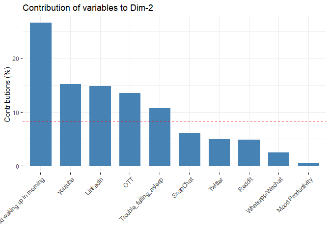

```r
fviz_contrib(pca_result, choice = "var", axes = 2, top = 10)
```

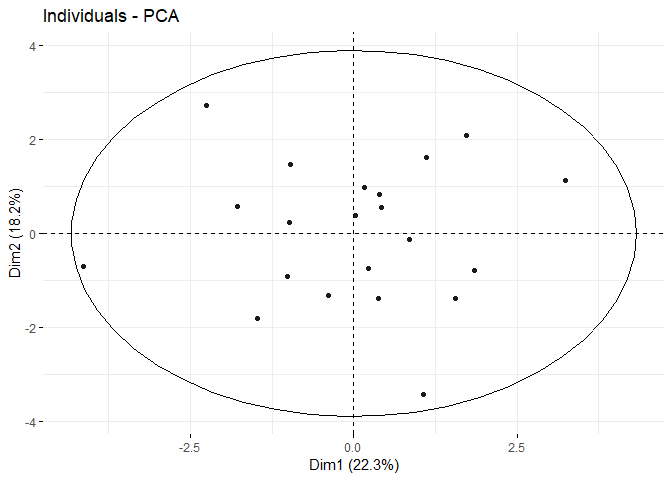

```r
# Visualize individual contributions
fviz_pca_ind(pca_result,
             geom.ind = "point", # Show points only
             palette = c("#00AFBB", "#E7B800", "#FC4E07"),
             addEllipses = TRUE, # Concentration ellipses
             legend.title = "Groups"
)
```

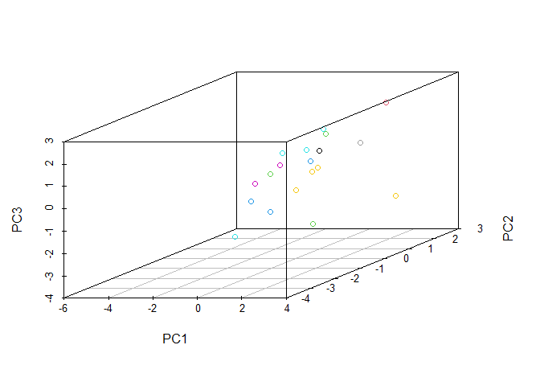

```r
scatterplot3d(pca_result$x[,1:3], color = social_media$Instagram)
```

### Cluster Analysis

```r
social_media_cluster <- read_excel("social_media_cleaned.xlsx")
data.scaled <- scale(x = social_media_cluster[, -1], center = TRUE, scale = TRUE)
data <- data.scaled
head(data)
```

```
##       Instagram   LinkedIn   SnapChat     Twitter Whatsapp/Wechat    youtube
## [1,] -0.6888867  0.1519097 -0.2810325  3.42451853      -1.3480276 -0.2719612
## [2,]  0.5146906  0.6366870  0.4933528 -0.44951033      -0.5576781  0.7352180
## [3,] -0.6130708  1.3638528 -0.4157082 -0.44951033       0.8450887 -0.6460563
## [4,] -0.1534369  0.6838181 -0.1944552 -0.44951033      -0.2804351 -0.5597267
## [5,]  1.7277449 -1.2283589 -0.5696232  0.06702685      -0.8514729  0.3035697
## [6,] -1.0205812  1.3638528 -0.4349475 -0.44951033       1.3830228  2.3179281
##             OTT     Reddit Trouble_falling_asleep Mood Productivity
## [1,]  3.4382238  1.2405563             -0.6900656         0.2182179
## [2,] -0.6686547 -0.3292004              1.3801311         0.2182179
## [3,] -0.1021887 -0.3292004             -0.6900656         0.2182179
## [4,] -0.1021887 -0.3292004             -0.6900656         0.2182179
## [5,] -0.1021887  0.2987023              1.3801311         0.2182179
## [6,]  0.1810443 -0.3292004             -0.6900656         0.2182179
##      Tired waking up in morning How you felt the entire week?
## [1,]                 -0.6900656                    -0.5741693
## [2,]                 -0.6900656                    -0.5741693
## [3,]                 -0.6900656                     0.7655590
## [4,]                 -0.6900656                     0.7655590
## [5,]                  1.3801311                    -0.5741693
## [6,]                 -0.6900656                     2.1052873
```

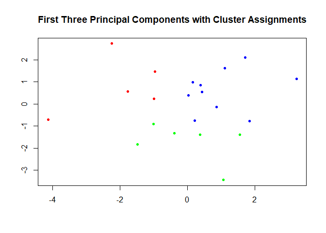

```r
# Perform PCA
pc <- prcomp(data.scaled)
pc_first_three <- pc$x[, 1:3]
# Perform K-means clustering on the first three principal components
set.seed(123)  # For reproducibility
k <- 3  # Number of clusters
km_clusters <- kmeans(pc_first_three, centers = k)

# Define colors for each cluster
cluster_colors <- c("red", "blue", "green")

# Plot the first three principal components with cluster assignments
plot(pc_first_three, col = cluster_colors[km_clusters$cluster],
     main = "First Three Principal Components with Cluster Assignments",
     xlab = "", ylab = "", pch = 20)
```

To reduce the dimensionality of the data, it first applies Principal Component Analysis (PCA) on scaled data.

The first three major components are then extracted. After that, it divides the data into three clusters using K-means clustering on these components.

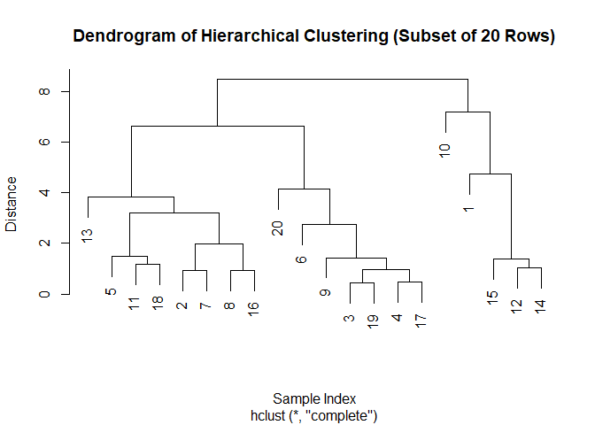

```r
# Take a subset of 20 rows
data_subset <- data[1:20, ]

# Perform PCA
pca_result <- prcomp(data_subset)

# Extract the first three principal components
pc_first_three <- pca_result$x[, 1:3]

# Perform hierarchical clustering on the first three principal components
hc <- hclust(dist(pc_first_three))

# Plot the dendrogram
plot(hc, main = "Dendrogram of Hierarchical Clustering (Subset of 20 Rows)",
     xlab = "Sample Index", ylab = "Distance", sub = NULL)
```

Plotting the first three principal components, a dendrogram illustrating the relationships between the samples based on their distances in the reduced-dimensional space, and hierarchical clustering on the plot are all displayed.

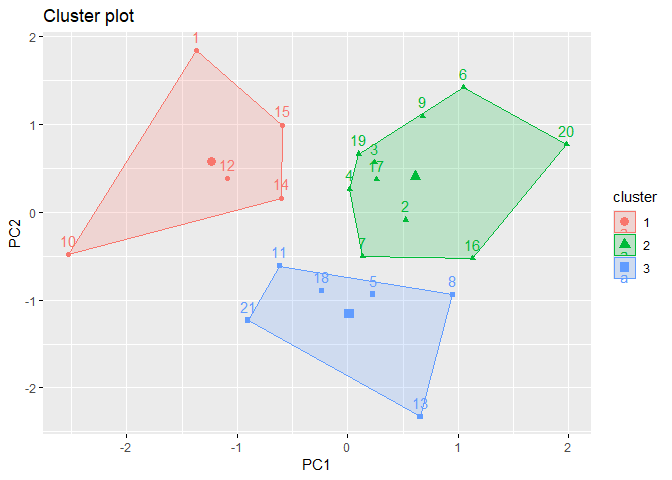

```r
# Visualize cluster and membership using first two Principal Components
fviz_cluster(list(data = pc$x[, 1:2], cluster = km_clusters$cluster))
```

By employing the first two Principal Components to plot data points in a two-dimensional space, this figure illustrates the effects of clustering. To display the grouping pattern found by the clustering algorithm, each point is colored in accordance with the cluster to which it has been assigned. It facilitates comprehension of how characteristics are used to group data items.

```r
# Non-hierarchical clustering (k-means)
num_clusters <- 2
kmeans_model <- kmeans(data, centers = num_clusters)

# Membership for each cluster
table(kmeans_model$cluster)
```

```
##
##  1  2
## 17  4
```

This is an example of splitting data into two clusters and clustering using the k-means algorithm. Cluster centers are initialized at random, and every data point is assigned to the closest cluster. The table function provides information on cluster membership and dispersion by counting the number of data points assigned to each cluster.